# Project 2

## Introduction (20 points)

#### 5 points for specific, measurable, and clear scientific question.

Scientific question: Knowing that altering the expression of specific marker genes in pluripotent cells can generate hepatocyte-like cells (HLCs), are the expression level of those marker genes similar in HLCs and primary hepatocytes?

#### 5 points for background on the protein/gene/species of interest and where the data is sourced from.

Background: Hepatocyte-like cells (HLCs) are cells that are derived from other cell types (such as induced pluripotent stem cells and fibroblasts), while having similar biological functions as primary hepatocytes do (Huang et al., 2011). Considiring the worldwide shortage of donor livers available for studies of genetic aspects of human hepatic disease and orthotropic liver transplants (Si-Tayeb et al., 2010), HLCs is a good alternative source for both clinical and research use.

HLCs are induced by alternating the expression of several marker genes in pluripotent cells and fibrobalsts. In previous studies using mouse models, it was found HLCs can be induced by altering the expression of the following marker genes: FOXA2, GATA4, and HNF4A (Si-Tayeb et al., 2010). Another study using pig models have found that altering the expression of CEBPα can also induce HLCs (Fráguas-Eggenschwiler., 2021).

It was proved using mice models that correctly induced HLCs were able to restore liver functions in vivo (Huang et al., 2011). However, this technology is still immature: A group of HLCs were found to have unnatural high expression of Cdx2 (a marker for intestinal differentiation) compared to PHHs, causing those HLCs to hve impaired hepatic functions (Morris et al., 2014). In addition, even for HLCs that have normal hepatic function, the overall gene expression pattern of those HLCs greately differs from that of primary hepatocytes (PHHs) (Gao et al., 2017). This difference may be inevitable since the HLCs do come from a cell source than the PHHs do. However, we expect the marker genes that are altered to induced differenticaion to have similar expressions in functional HLCs and PHHs, since in theory, only cells with correct level of those genes can be induced to PHHs. We will also expect similar expression levels of marker genes for other cell types (such as Cdx2) in functional HLC and PHHs, since high expression levels of other cell type’s marker gene may cause impared hepatic function.

#### 5 points for clear, specific, and measurable scientific hypothesis that is in the form of an if-then statement.

Therefore, we propose the following hypothesis: If a hepatocyte-like cell (HLC) has phenotypes similar to natural hepatocytes, then no matter what the induction method is or how the general gene expression pattern differs, its expression of the following marker genes - FOXA2, GATA4, HNF4a, CEBPα, CDX2 - should also be similar to natural hepatocytes.

#### 5 points for description of what analyses were done and how the data was downloaded for the project.

My analysis contains 2 parts: The first part will be pairwise sequence alignment. The discovery of FOXA2, GATA4, HNF4a being markers for HLCs and CDX2 being the reason for impaired hepatic function is based on mouse models, and the discovery of CEBPα being HLC markers is based on pig models; By performing pairwise sequence alignment on those genes and their human analog, we can see the similarity of the genes between species. For example, we can align the human CEBPα and pig CEBPα, and if the alignment score is high, we say this gene is similar in humans and pigs, thus we can assume that CEBPα is also a hepatocyte marker gene in humans, and altering CEBPα can help with inducing human cells into HLCs. Similarly, if the alignment score is low, CEBPα may not play a similar role in humans and not be a marker gene. In this case, if all 4 other genes have similar expression in HLCs and hepatocytes while CEBPα doesn’t, the hypothesis (the expression of marker genes in HLCs and hepatocytes are similar) can still be true, since CEBPα may not be a marker gene in human. The fasta files used for alignment are mRNA sequences downloaded from NCBI nucleotide (specific accession number as listed below).

1. Mouse FOXA2: NM_001291065.1
2. Human FOXA2: NM_021784.5
3. Mouse GATA4: NM_001310610.1
4. Human GATA4: NM_001308093.3
5. Mouse HNF4a: NM_001312906.1
6. Human HNF4a: NM_000457.6
7. Pig CEBPα: XM_003127015.4
8. Human CEBPα: NM_001285829.2
9. Mouse CDX2: NM_007673.3
10. Human CDX2: NM_001354700.2

The second part will be RNAseq analysis, which will be used to measure the expression level of each gene, and it will output a table where each gene has a pval. By checking the pval of the 5 target gene, we can see if their expression levels differ in HLC and hepatocytes. The fastq files are downloaded from NCBI GEO, (https://www.ncbi.nlm.nih.gov/geo/query/acc.cgi?acc=GSE103078), and it is the sequencing results of 4 hiHeps (HLC1), 4 iPSC-HLCs (HLC2), and 4 primary hepatocytes. hiHeps and iPSC-HLCs are both HLC, but they are inducted from different cells using different induction methods.

## Loading in Packages (15 points)

#### 10 points for definition of each of the packages loaded.

The following packages will be loaded:

1. stringr: a string processing package that contain the function str_split, which is used for spliting a string while generating metatable for RNAseq.
2. sjmisc: a string processing package that contain the function str_contains, which is used for spliting a string while generating metatable for RNAseq.
3. rhdf5: a package that provides an interface between HDF5 and R. This package is required for reading h5 files into R while using tximport.
4. tximport: a package used for importing alignment results of multiple samples (such as h5 files outputted by kallisto) into R as a count matrix.
5. EnsDb.Hsapiens.v75: Ensembl based annotation package, needed for generating the gene list required by tximport so that alingment results can be converted to count matrix. It is also used for converting the ENSG gene ids into gene names.
6. DESeq2: package that runs differential gene expression analysis based on the negative binomial distribution.
7. Biostrings: package for read in fasta files as strings.
8. DECIPHER: use to color code the alignment results
9. dplyr: package needed for data manipulation; it’s mutate function is used while plotting volcano plot.
10. ggplot2: package needed for plotting volcano plot.
11. pheatmap: package needed for plotting a heatmap of expression of same genes across samples.
12. ggrepel: package need for adding text label to the volcano plot.

#### 5 points for correctly loading all of the packages needed and stating anything that needs to be done to load the packages (downloading the packages)

The following package can be directly downloaded via “install.packages()”:

```r
##
# string/data wrangling packages
library(dplyr)
library(stringr) ## needed for str_split
library(sjmisc) ## needed for str_contains

# plotting packages
library(ggplot2)
library(ggrepel)
library(pheatmap)
```

The folling package need to be downloaded via bioconductor: for exapmle, “BiocManager::install(”ggmsa”)“.

```r
## Packages for alignment
library(Biostrings)
library(DECIPHER)

# Packages for RNAseq
library(rhdf5) ## needed for reading h5 files
library(tximport)
library(DESeq2)
library(EnsDb.Hsapiens.v75) ## needed for generating tx2 gene list and map ensg to gene name
```

## Performing Bioinformatics Analysis - 1

#### 5 points for a description each of the bioinformatics method that includes data types read in and how the method works.

#### 5 points for comments identifying global variables and local variables with in depth explanations of each

#### 5 points for code working correctly

#### 5 points for adequate commenting in the code and code checks

#### 5 points for a function written that performs some part of the bioinformatics analyses

#### 5 points for hard-coding/redundant code being absent.

Part1: use pairwise sequence alignment to compare similarity of human genes with their animal anaologs. This will be used on mRNAs, since the whole genome sequene contain too much introns that will make the alignment too long. Pairwise sequence alignment will read in two mRNA sequences and several parameters (scores for match/mismatch/gapopen/gapextension/alignment type). The pairwiseAlignment function will use the Needleman-Wunsch algorithm for global alignment or the Smith-Waterman algorithm for local alignment to align the two sequences using the given parameters. The function will return a ‘PairwiseAlignmentsSingleSubject’ object, and we will focus on the alignment score, the percent sequence identity of the object to check how similar the 2 sequences are, and use the consensus sequence and color coded alignment result to visualize where the gaps/mismatches are.

```r
## read in fastas for the 10 genes and store them in a global variable called fastas; the file genes.fasta stores all 10 genes; since fastas is a global variable, it can be accessed throughout the whole notebook.
fastas <- readAAStringSet("fastas/genes.fasta")

## define a function that takes in a gene name and prints the alignment results between that human gene and it's animal analog
align <- function(name,fasta){
  cat("For human gene", name, "and it's animal analog: \n") ## print out the gene name

  ## loop through every sequence in the fasta file
  for(i in 1:length(fasta)){
    ## check if the current sequence names contains the target gene name we want to compare between species
    if(str_contains(toupper(names(fasta[i])), name)){
      seq1 <- fasta[i] ## assign the human version of target gene to local variable seq1; seq1 is a local variable, since it can only be accessed in this function
      seq2 <- fasta[i+1] ## assign the animal version of target gene to local variable seq2; similarly seq2 can only be accessed inside this function
      mat <- nucleotideSubstitutionMatrix(match = 1, mismatch = -1, baseOnly = TRUE)# define a alignment scoring matrix, with match = 1, mismatch = -1
      alg <- pairwiseAlignment(pattern = seq1, subject = seq2,type="local",substitutionMatrix = mat, gapOpening = 5, gapExtension = 1)# do local alignment since there we are aligning mRNA, which could be different due to splicing; pattern and subject are the 2 sequences we want to compare

      ## print out the consensus seq, the alignment score, and percent sequence identity
      cat("The local consensus sequence is: \n")
      print(compareStrings(alg)) ## get consensus sequence
      cat("The alignment score is: ", score(alg)) ## get alignment score
      cat("\n")
      cat("The percent sequence identity is: ", pid(alg)) ## get percent sequence identity
      cat("\n")

      seq <- c(alignedPattern(alg), alignedSubject(alg)) # store the aligned pattern of the 2 sequences into a vector to be visualized
      BrowseSeqs(seq, htmlFile = paste(name, ".html", sep = "") ) ## get a color coded version of the whole alignment; while running the notebook, this line of code will create a html named genename.html(for example,CDX2.html) that contains the color coded alignment result and automatically opens it.
      break # break so we only align one pair at a time
    }
  }
}
```

```r
# align the 5 target genes and their animal analogs; print out consensus sequences, alignment scores, and percent sequence identity
align("CDX2",fastas)
```

```
For human gene CDX2 and it's animal analog:
The local consensus sequence is:
[1] "TCCGC??GCCA?CCTG?GGCGGGTC?TCCCCGCCTCT?CAGC?TA?TGG?AAGGAGGTGGGAGGAAAGAAGGAAGA?AGGG+++++++GAGGAGGCAGG?C?GAGGGAGGGAC?GCC??GGAGGCAGAAG??C?GC?AGGAGCC??CGGAGCACCG?GGGCTG?GG?GCAGCCA?C??CC??T??+++++++C?CT?GCCCC?T?C?C?TCG?GCC?C?+GGCAGCCT?CA?CGT??GTCCCCAG?CAGCATGGTGAGGTCTGCTC??GG?CCCTCGCCACCATGTACGTGAGCT…
The alignment score is:  1015
The percent sequence identity is:  75.83109
```

```r
align("CEBPA",fastas)
```

```
For human gene CEBPA and it's animal analog:
The local consensus sequence is:
[1] "ATTCGCGACC?GGAG?TGCGCGGGCGCG?G?GAG?AGGGTCTCCGGGTGGGC?GCGGC------G?CGCCCCGCGC?GGCTGGAGGCCGCCGAGGCTCGCCATGCCGGGAG?ACTCTA?CTCCCCCATGGAGTCGGCCGACTTCTACGAGGCGGAGCCGCGGCCCCCGATGAGCAGCCACCT?CAGAGCCCCCCGCACGCGCCCAGCAGCGCCGCCTTCGGCTTTCCCCGGGGCGCGGGCCCCGCGCAGCC?CC?GCCCCACCTGCCGCCCCGGAGCCGCTGGGCGGCATCTGCG…
The alignment score is:  1701
The percent sequence identity is:  84.18914
```

```r
align("FOXA2",fastas)
```

```
For human gene FOXA2 and it's animal analog:
The local consensus sequence is:
[1] "GGTCGTTTGTTGTGGCTGTTAAATTTTAAAC?GCCATGCACTCGGCTTCCAGTATGCTGGGAGC?GTGAAGATGGAAGGGCACGAGCC?TCCGACTGGAGCAGCTACTA?GC?GAGCCCGAGGGCTACTC?TCCGTGAGCAACATGAACGCCGGCCTGGGGATGAA?GGCATGAACAC?TACATGAGCATGTC?GCGGC?GCCATGGGC?GCGG?TC?GGCAACATGAGCGCGGGCTCCATGAACATGTC?TC?TA?GTGGGCGCTGG?ATGAGCCCGTC?CT?GC?GG?ATGTC…
The alignment score is:  1346
The percent sequence identity is:  83.53716
```

```r
align("GATA4",fastas)
```

```
For human gene GATA4 and it's animal analog:
The local consensus sequence is:
[1] "ATGTA?CA?AGC?TGGCCATGGCCGCCAACCACGG?CC?CC?CCCGG?GCCTACGA?GC?GG?GGCCC?GGCGCCTTCATGCAC?GCGCGGGCGCCGCGTCCTCGCC?GTCTACGTGCCCAC?CCGCGGGTGCC?TCCTC?GTGCTGGGCCTGTCCTACCT?CAGGGCGG?GGC???G?C?CTGC??C?GGA??C?CCTCGGG?GGCAGCTCCGG?G??G?C?CGTC?GGTGC?GGGCC?GGGACCCAGCAGGG?AGCCC?GG?TGGAGCCA?GC?GGAGCCGA?GGAGCCGC?T…
The alignment score is:  978
The percent sequence identity is:  87.39746
```

```r
align("HNF4A",fastas)
```

```
For human gene HNF4A and it's animal analog:
The local consensus sequence is:
[1] "GACACGTCCCCATC?GAAGG??CCAACCTCAA??C??CCAACAGCCTGGG?GTCAG?GCCCTGTG?GCCATCTG?GG?GACCGGGCCAC?GGCAAACACTACGG?GCCTCGAGCTGTGACGGCTGCAAGGG?TTCTTC?GGAGGAGCGTG?GGAAGAACCACATGTACTCCTGCAG?TTTAGCCG?CA?TG?GTGGT?GACAAAGA?AAGAGGAACCAGTG?CG?TACTGCAGGCT?AAGAA?TGCTTCCGGGCTGGCATGAAGAAGGAAGC?GTCCA?AATGAGCGGGACCGGA…
The alignment score is:  1134
The percent sequence identity is:  81.00102
```

## Analyzing the Results - 1

For all 5 genes, most percent sequence identity exceeds 80% and the alignment score is around 1000; Considering those are mRNA sequences and there could be different splicing patterns, dissimilarity to some extent is expected, and having 80% percent sequence identity indicates high similarity; therefore we conclude all 5 human genes are similar with their animal analogs, and as in mice and pigs, CEBPA, FOXA2, GATA4, HNF4A should be liver marker genes, and CDX2 should be marker for intestinal differentiation. Thus according to our hypothesis, all five genes should have similar expression levels in HLCs and PHHs.

## Performing Bioinformatics Analysis - 2

Part2: use RNAseq to determine if target gene have similar expression in HLC and hepatocytes. RNAseq is designed to compare the expression level of each gene between two conditions: it will take in a gene count matrix and a metatable that records which condition each sample belong. It will normalize the count matrix, compare the expression level between two groups using Wald test, and return a dataframe, in which each row is a gene, and every gene is given an adjusted p-value and a log2foldchange; if the adjusted p-value is smaller than 0.05, we say the expression of that gene differes between the two conditions.

The raw fastq files (GSE103078) are aligned using command line alignment tool kallisto; the alignment results is stored in h5 files, which can be imported into R as a gene count matrix using tximport.

```r
#get information about human transcripts; to import the h5 files using tximport, we need a dataframe that maps transcripts id to gene id
txRaw <- transcripts(EnsDb.Hsapiens.v75, return.type = "DataFrame")
#select only the transcript id and gene id column
tx2gene <- data.frame(txRaw$tx_id,txRaw$gene_id,stringsAsFactors = TRUE)
# rename the dataframe columns
names(tx2gene)<-c("transcript_id","gene_id")
head(tx2gene)
```

|  | transcript_id | gene_id |
| --- | --- | --- |
| 1 | ENST00000387314 | ENSG00000210049 |
| 2 | ENST00000389680 | ENSG00000211459 |
| 3 | ENST00000609761 | ENSG00000273089 |
| 4 | ENST00000602027 | ENSG00000268590 |
| 5 | ENST00000408670 | ENSG00000221597 |
| 6 | ENST00000466464 | ENSG00000241000 |

```r
#get a metatable
# filenames.txt is the names of the raw fastq files (such as hiHep1_mRNA.fastq.gz); it is generated by running ls | grep "gz" >> filenames.txt

fastqs <- read.csv('kallisto/filenames.txt',sep = "\n",header = FALSE)

#get the row names
metaNames <- vector(mode="character", length=12)
for (i in 1:nrow(fastqs)) {
    str <- paste(fastqs[i,1])
    x <- str_split(str, "_mRNA",simplify = TRUE)  ##get the cell name
    if(str_contains(x[1,1], "iPSC")){  #the iPSC is named as hiPSC, but the article where the dataset came from uses iPSC; rename as iPSC
        y <- gsub("h", "", x[1,1])
        metaNames[i] <- y
    }else{
        metaNames[i] = x[1,1]
    }
}

#get folder names (name of folders that contain h5 files)
folderNames <- vector(mode="character", length=12)
for (i in 1:nrow(fastqs)) {
    str <- paste(fastqs[i,1])
    x <- str_split(str, ".fastq",simplify = TRUE)
    folderNames[i] = x[1,1]
}

#get the conditions
cond <- vector(mode="character", length=12) # cond have 3 types:hiHep, iPSC, and PHH; both hiHep and iPSC are hepatocyte like cells, but are induced from different cells and used different induction methods

cond2 <- vector(mode="character", length=12) # cond2 have 2 types: HLC and PHH. Both hiHep and iPSC are HLC.
for (i in 1:length(folderNames)){
    if(str_contains(folderNames[i], "hiHep")){
        cond[i] <- "hiHep"
        cond2[i] <- "HLC"
    }else if (str_contains(folderNames[i], "hiPSC-Hep")){
        cond[i] <- "iPSC.Hep"
        cond2[i] <- "HLC"
    }else if (str_contains(folderNames[i], "PHH")){
        cond[i] <- "PHH"
        cond2[i] <- "PHH"
    }
}

## form metatable
samples <- data.frame(folderNames,cond,cond2,stringsAsFactors = TRUE)
names(samples)<-c("folderNames","condition","condition_2")
rownames(samples)<-metaNames
head(samples,12)
```

|  | folderNames | condition | condition_2 |
| --- | --- | --- | --- |
| hiHep1 | hiHep1_mRNA | hiHep | HLC |
| hiHep2 | hiHep2_mRNA | hiHep | HLC |
| hiHep3 | hiHep3_mRNA | hiHep | HLC |
| hiHep4 | hiHep4_mRNA | hiHep | HLC |
| iPSC-Hep1 | hiPSC-Hep1_mRNA | iPSC.Hep | HLC |
| iPSC-Hep2 | hiPSC-Hep2_mRNA | iPSC.Hep | HLC |
| iPSC-Hep3 | hiPSC-Hep3_mRNA | iPSC.Hep | HLC |
| iPSC-Hep4 | hiPSC-Hep4_mRNA | iPSC.Hep | HLC |
| PHH_0d | PHH_0d_mRNA | PHH | PHH |
| PHH_1d | PHH_1d_mRNA | PHH | PHH |

[output cut: 2 more lines]

```r
#get the path to the abundance files; it's needed for tximport
paths <- samples$folderNames
files <- file.path("kallisto",paths, "abundance.h5")
names(files) <- metaNames
# check if all file exists
all(file.exists(files))
```

```
[1] TRUE
```

#### 5 points for use of a built-in Bioconductor or Biopython function (or some other tool that was discussed in class like NumPy or SciPy), and a description of what the function reads in and what it returns

tximport is a built-in Bioconductor funtion: it reads in a list of files that contains alignment results (such as h5 files outputted by kallisto) and a dataframe that maps transcripts to genes (the variable tx2gene in this case), and returns a count matrix that records the abundance of each gene across samples. The returned count matrix will be used for downstream statistical analysis such as DEseq2.

```r
#Translate kallisto results to gene count tables using tximport
#import results base on genes, not transcripts
txi.kallisto <- tximport(files, type = "kallisto", tx2gene = tx2gene, txOut = FALSE,ignoreAfterBar = TRUE,abundanceCol = "TPM")
```

```
1 2 3 4 5 6 7 8 9 10 11 12
transcripts missing from tx2gene: 10051
summarizing abundance
summarizing counts
summarizing length
summarizing inferential replicates
```

```r
head(txi.kallisto$counts)
```

```
                  hiHep1   hiHep2   hiHep3
ENSG00000000003 317.6453 264.1520 450.9980
ENSG00000000005   3.0000   3.0000  16.0000
ENSG00000000419 397.0000 381.5525 499.2386
ENSG00000000457 158.7843 189.2350 184.9831
ENSG00000000460 282.6807 323.7259 304.4283
ENSG00000000938   4.0000   0.0000   8.0000
                    hiHep4 iPSC-Hep1 iPSC-Hep2
ENSG00000000003 405.770928 488.99624  535.4099
ENSG00000000005   3.000000   0.00000    1.0000
ENSG00000000419 448.642400 192.66418  231.0694
ENSG00000000457 160.687479  91.33579  137.8181
ENSG00000000460 241.272201 121.27312  194.5836
ENSG00000000938   6.364486   2.00000    0.0000
                iPSC-Hep3 iPSC-Hep4    PHH_0d
ENSG00000000003  578.8983 656.02585 802.70301
ENSG00000000005    4.0000   2.00000   0.00000
ENSG00000000419  175.9740 179.05172 177.42272
ENSG00000000457  124.2341  97.59367 179.90089
ENSG00000000460  150.5206  86.98116  43.50357
ENSG00000000938    1.0000   0.00000   1.00000
                   PHH_1d   PHH_2d     PHH_4d
ENSG00000000003 403.58696 494.4243 555.126279
ENSG00000000005   0.00000   0.0000   0.000000
ENSG00000000419 589.78669 543.5187 458.668298
ENSG00000000457 175.98786 173.4428 147.676254
ENSG00000000460  60.85197 108.9596 119.078455
ENSG00000000938  12.68620  14.0000   7.188745
```

```r
## Run a PCA to check if the overall gene expression differes between HLCs and PHHs
## The plotting will be done in the "plotting result" section
dds <- DESeqDataSetFromTximport(txi.kallisto, colData = samples, design = ~condition)
```

```
using counts and average transcript lengths from tximport
```

```r
#Use vst to normalize counts
vsd <- vst(dds, blind=FALSE)
```

```
using 'avgTxLength' from assays(dds), correcting for library size
```

```r
vsdM <- t(assay(vsd)) #vsdM: vsd Matrix, the transpose of normalized raw counts
#Run PCA on transformed data
vsdPCA <- prcomp(vsdM)
## get the label for the points
label <- factor(paste(samples$condition))
```

```r
## create DEseq object
dds <- DESeqDataSetFromTximport(txi.kallisto, colData = samples, design = ~condition_2)
```

```
using counts and average transcript lengths from tximport
```

```r
## run differential expression analysis
dds <- DESeq(dds)
```

```
using 'avgTxLength' from assays(dds), correcting for library size
-- replacing outliers and refitting for 546 genes
-- DESeq argument 'minReplicatesForReplace' = 7
-- original counts are preserved in counts(dds)
```

```r
## store DEseq result to global variable res as a dataframe
res <- as.data.frame(results(dds, contrast=c("condition_2","HLC","PHH")))
```

```r
# for each ensg, find the corresponding gene name
tmp <- ensembldb::select(EnsDb.Hsapiens.v75, keys= rownames(res), keytype = "GENEID", columns = c("GENEID","SYMBOL"))
# get a dataframe which's rownames are ensg, and the only column is gene names; store it to global varialbe tmp2
tmp2 <- data.frame(tmp$SYMBOL)
rownames(tmp2) <- tmp$GENEID
# combine res and tmp2, so we can access row in res by gene names
res <- merge(res, tmp2,by = 'row.names', all = TRUE)
head(res)
```

|  | Row.names | baseMean | log2FoldChange | lfcSE | stat | pvalue | padj | tmp.SYMBOL |
| --- | --- | --- | --- | --- | --- | --- | --- | --- |
| 1 | ENSG00000000003 | 548.266491 | -0.9355402 | 0.4232965 | -2.210130 | 0.027096166 | 0.07240327 | TSPAN6 |
| 2 | ENSG00000000005 | 2.386700 | 3.9629002 | 1.5018867 | 2.638615 | 0.008324556 | 0.02820446 | TNMD |
| 3 | ENSG00000000419 | 349.131670 | -0.7966238 | 0.3168225 | -2.514417 | 0.011922951 | 0.03769867 | DPM1 |
| 4 | ENSG00000000457 | 161.118358 | -0.7872473 | 0.3297886 | -2.387127 | 0.016980622 | 0.04987473 | SCYL3 |
| 5 | ENSG00000000460 | 160.756680 | 1.0332278 | 0.3786530 | 2.728693 | 0.006358589 | 0.02264864 | C1orf112 |
| 6 | ENSG00000000938 | 4.015872 | -1.7839168 | 0.9563518 | -1.865335 | 0.062134421 | 0.13825000 | FGR |

```r
# select our target genes
genes <- c("CDX2","CEBPA","GATA4","FOXA2","HNF4A")
res[res$tmp.SYMBOL %in% genes, ]
```

|  | Row.names | baseMean | log2FoldChange | lfcSE | stat | pvalue | padj | tmp.SYMBOL |
| --- | --- | --- | --- | --- | --- | --- | --- | --- |
| 2451 | ENSG00000101076 | 2632.6431 | 0.7285539 | 0.4010103 | 1.8167962 | 6.924832e-02 | 1.501500e-01 | HNF4A |
| 5752 | ENSG00000125798 | 194.6902 | -2.3383959 | 1.3010273 | -1.7973458 | 7.228075e-02 | 1.549729e-01 | FOXA2 |
| 7351 | ENSG00000136574 | 405.6594 | 0.6448430 | 1.3587539 | 0.4745841 | 6.350835e-01 | 7.485807e-01 | GATA4 |
| 11728 | ENSG00000165556 | 285.2889 | 10.5334229 | 1.6678712 | 6.3154896 | 2.693075e-10 | 7.256797e-09 | CDX2 |
| 32991 | ENSG00000245848 | 769.4255 | 1.7730365 | 2.2745581 | 0.7795081 | 4.356805e-01 | 5.773945e-01 | CEBPA |

## Plotting The Results (15 points)

## Analyzing the Results - 2 (15 points)

#### 5 points for description of data analysis method

#### 5 points for the code working for data analysis method

#### 5 points for adequate commenting in the code for the data analysis method

PCA is a dimensionality-reduction method. Our gene expression data is multi-dimensional (each gene is a dimension), so we need PCA to reduce dimension. I plot the score plot of the PCA we ran in “Performing Bioinformatics Analysis - 2”: the score plot indicates the projection of the data onto the span of the PC1 and PC2, which are the PCs that explains the most variation. In the score plot, each dot represents a sample. Two dots being close to each other indicates two samples have similar overall gene expression.

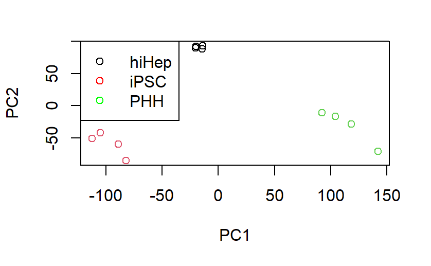

```r
## plot PCA
plot(vsdPCA$x[, c(1, 2)], col = label,
     xlab = "PC1", ylab = "PC2")
## add legend to plot
legend( x="topleft",
        legend=c("hiHep","iPSC","PHH"),
        col=c("black","red","green"), lwd=1, lty=c(0,0,0),
        pch=c(1,1,1) )
```

We can see in terms of overall gene expression levels, not only HLCs differ from PHHS, the 2 types of HLCs also differs from each other. This agrees with previous findings.

A volcano plot is a type of scatterplot that shows padj versus log2fold change. In our volcano plot, each point represents a gene; genes that are above the padj thershold (padj < 0.05) are colored in blue, and the ones that are below threshold are colored in red. In other words, the blue genes’ expression level is different in HLCs and PHHs. Our five target genes are labeled in the plot.

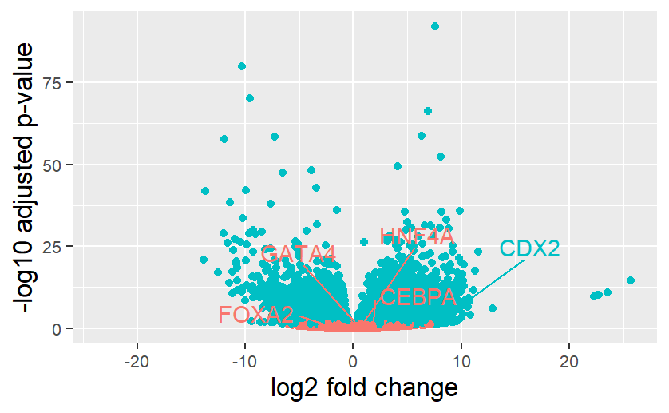

```r
## add a threshold column to the res dataframe, so we can use this column to color the dots in the volcano plot
res_all <- data.frame(res) %>% mutate(threshold = padj < 0.05)

## plot volcano plot with label
ggplot(res_all, aes(x = log2FoldChange, y = -log10(padj), color = threshold)) + geom_point() + geom_text_repel(data = res_all %>% dplyr::filter(tmp.SYMBOL %in% genes),
            aes(label = tmp.SYMBOL, x = log2FoldChange, y = -log10(padj)), box.padding = unit(.7, "lines"),hjust= 0.30) +
        xlab("log2 fold change") +
        ylab("-log10 adjusted p-value") +
        theme(legend.position = "none", text = element_text(size = 10),
              plot.title = element_text(size = rel(1.5), hjust = 0.5),
              axis.title = element_text(size = rel(1.25)))
```

A heatmap is a data visualization technique that shows magnitude of a phenomenon as color in two dimensions. The heatmap below shows the expression level of the 5 genes across all samples. Each row is a gene and each column is a sample. The redder a cell is, the higher a certain gene expresses in a certain sample. Base on the expression level of the five genes, samples with similar expression levels are clustered together using hierarchical clustering.

[figure not shown]

```r
# get the normalized counts form dds
counts <- counts(dds, normalized=TRUE)

#select out five target genes from the res dataframe
ensg <- res[res$tmp.SYMBOL %in% genes, ]$Row.names
counts_sub <- counts[ensg,]
rownames(counts_sub) <- genes

## plot the heatmap
pheatmap(counts_sub)
```